# neural_network_walkthrough

Hazem Mslati_10599158

4/4/2022

# Introduction to Neural Networks (Deep Learning)

## 1. Load Data

- First we start with our imports

```python
import pandas as pd
import numpy as np
import seaborn as sns

from keras.models import Sequential ## we will implement our neural networks from the keras lib
from keras.layers import Dense

import matplotlib.pyplot as plt
from termcolor import colored
import statsmodels.api as sm
from scipy.stats import pearsonr
#%matplotlib inline
```

- Next we load our dataset

I am going to use the Pima Indians onset of diabetes dataset. You can donwload the dataset from this link: https://www.kaggle.com/datasets/uciml/pima-indians-diabetes-database

Briefly, this dataset the Pima Indian Diabetes Dataset, it is originally from the National Institute of Diabetes and Digestive and Kidney Diseases. It contains information of 768 women from a population near Phoenix, Arizona, USA. The outcome tested was Diabetes. Therefore, there is one target (dependent) variable and the 8 attributes (TYNECKI, 2018): pregnancies, OGTT(Oral Glucose Tolerance Test), blood pressure, skin thickness, insulin, BMI(Body Mass Index), age, pedigree diabetes function.

```python
pima = pd.read_csv('diabetes.csv')
```

## 2. Exploratory data analysis (EDA)

The variables can be summarized as follows:

Input Variables (X):

Number of times pregnant Plasma glucose concentration a 2 hours in an oral glucose tolerance test Diastolic blood pressure (mm Hg) Triceps skin fold thickness (mm) 2-Hour serum insulin (mu U/ml) Body mass index (weight in kg/(height in m)^2) Diabetes pedigree function Age (years) Output Variables (y):

Class variable (0 or 1)

*The shape of the data*

```python
print(f"Shape of dataset: {colored(pima.shape, 'yellow')}")
```

```
## Shape of dataset: (768, 9)
```

*Preview of the first five rows*

```python
pima.head()
```

```
##    Pregnancies  Glucose  BloodPressure  ...  DiabetesPedigreeFunction  Age  Outcome
## 0            6      148             72  ...                     0.627   50        1
## 1            1       85             66  ...                     0.351   31        0
## 2            8      183             64  ...                     0.672   32        1
## 3            1       89             66  ...                     0.167   21        0
## 4            0      137             40  ...                     2.288   33        1
##
## [5 rows x 9 columns]
```

*Renaming DiabetesPedigreeFunction to DPF for better consistency*

```python
pima = pima.rename(columns = {'DiabetesPedigreeFunction':'DPF'})
```

*Checking the number of unique values in each column*

```python
dict = {}
for i in list(pima.columns):
    dict[i] = pima[i].value_counts().shape[0]

pd.DataFrame(dict,index=["unique count"]).transpose()
```

```
##                unique count
## Pregnancies              17
## Glucose                 136
## BloodPressure            47
## SkinThickness            51
## Insulin                 186
## BMI                     248
## DPF                     517
## Age                      52
## Outcome                   2
```

*Separating into features and possible target class*

```python
con_cols = list(pima.drop('Outcome',axis=1).columns)
target = ['Outcome']
print(f"The columns are : {colored(con_cols, 'yellow')}")
```

```
## The columns are : ['Pregnancies', 'Glucose', 'BloodPressure', 'SkinThickness', 'Insulin', 'BMI', 'DPF', 'Age']
```

```python
print(f"The target is   : {colored(target,'yellow')}")
```

```
## The target is   : ['Outcome']
```

*Summary statistics*

```python
pima[con_cols].describe().transpose()
```

```
##                count        mean         std  ...       50%        75%     max
## Pregnancies    768.0    3.845052    3.369578  ...    3.0000    6.00000   17.00
## Glucose        768.0  120.894531   31.972618  ...  117.0000  140.25000  199.00
## BloodPressure  768.0   69.105469   19.355807  ...   72.0000   80.00000  122.00
## SkinThickness  768.0   20.536458   15.952218  ...   23.0000   32.00000   99.00
## Insulin        768.0   79.799479  115.244002  ...   30.5000  127.25000  846.00
## BMI            768.0   31.992578    7.884160  ...   32.0000   36.60000   67.10
## DPF            768.0    0.471876    0.331329  ...    0.3725    0.62625    2.42
## Age            768.0   33.240885   11.760232  ...   29.0000   41.00000   81.00
##
## [8 rows x 8 columns]
```

*Count of target variable*

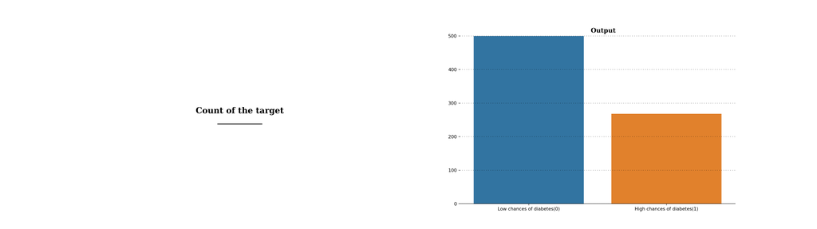

```python
fig = plt.figure(figsize=(25,7))
gs = fig.add_gridspec(1,2)
gs.update(wspace=0.3, hspace=0.15)
ax0 = fig.add_subplot(gs[0,0])
ax1 = fig.add_subplot(gs[0,1])

# Title of the plot
ax0.text(0.5,0.5,"Count of the target\n___________",
        horizontalalignment = 'center',
        verticalalignment = 'center',
        fontsize = 18,
        fontweight='bold',
        fontfamily='serif',
        color='#000000')

ax0.set_xticklabels([])
ax0.set_yticklabels([])
ax0.tick_params(left=False, bottom=False)
# Target Count
ax1.text(0.45,510,"Output",fontsize=14, fontweight='bold', fontfamily='serif', color="#000000")
ax1.grid(color='#000000', linestyle=':', axis='y', zorder=0,  dashes=(1,5))
sns.countplot(ax=ax1, data=pima, x = 'Outcome')
ax1.set_xlabel("")
ax1.set_ylabel("")
ax1.set_xticklabels(["Low chances of diabetes(0)","High chances of diabetes(1)"])

ax0.spines["top"].set_visible(False)
ax0.spines["left"].set_visible(False)
ax0.spines["bottom"].set_visible(False)
ax0.spines["right"].set_visible(False)
ax1.spines["top"].set_visible(False)
ax1.spines["left"].set_visible(False)
ax1.spines["right"].set_visible(False)

plt.show()
```

- we observe class imbalance from this bar plot.